# Math 335 Challenge Problem

# Background

Early in prehistory, some descriptive names began to be used again and again until they formed a name pool for a particular culture. Parents would choose names from the pool of existing names rather than invent new ones for their children.

With the rise of Christianity, certain trends in naming practices manifested. Christians were encouraged to name their children after saints and martyrs of the church. These early Christian names can be found in many cultures today, in various forms. These were spread by early missionaries throughout the Mediterranean basin and Europe.

By the Middle Ages, the Christian influence on naming practices was pervasive. Each culture had its pool of names, which were a combination of native names and early Christian names that had been in the language long enough to be considered native.

# Challenge Questions

## Challenge Question One

How does your name at your birth year compare to its use historically?

### Response

First we plot the number of children that were named James for each year in the data.

```r
library(tidyverse)
```

```r
names_year <- read_csv("names_year.csv")
```

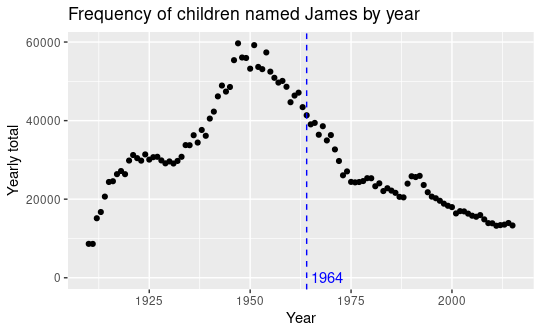

```r
getNameTibble <- function(x) names_year %>% filter(name==x) %>% select(c(year, Total))
james_data <- getNameTibble("James")
james_data %>% ggplot(aes(year, Total)) + geom_point() + labs(title="Frequency of children named James by year", x="Year", y="Yearly total") + geom_vline(xintercept=1964, linetype='dashed', color='blue') + annotate("text", x = 1969, y = 0, label = "1964", color = "blue")
```

I was born in the year 1964, in which there were 41359.5 children born with the name James. It looks like the name James was most popular around 1950, but that might be due to the baby boom after World War II, and not because the name James was more popular around that time period. To check this, we should look at the proportion of the children named James each year instead of the frequency for each year.

To calculate the proportions, we filter the original data by year, and then add up the frequency totals for each name to get a grand total for the number of children born that year. Then we divide the yearly total for James by the grand total for the year.

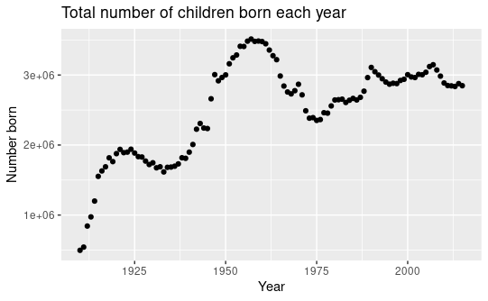

```r
getGrandTotal <- function(x) names_year %>% filter(year==x) %>% select(c(Total)) %>% sum()
james_data <- james_data %>% mutate(grandTotal = (year %>% modify(function(x) getGrandTotal(x))), propGrandTotal = Total/grandTotal)
james_data %>% ggplot(aes(year, grandTotal)) + geom_point() + labs(title="Total number of children born each year", x="Year", y="Number born")
```

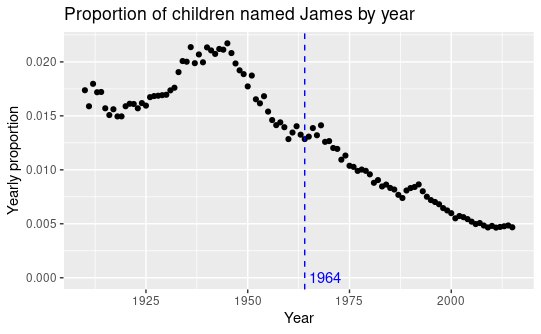

```r
james_data %>% ggplot(aes(year, propGrandTotal)) + geom_point() + labs(title="Proportion of children named James by year", x="Year", y="Yearly proportion") + geom_vline(xintercept=1964, linetype='dashed', color='blue')  + annotate("text", x = 1969, y = 0, label = "1964", color = "blue")
```

The rise in frequencies seen in the first graph from 1910 to the early 1940s is deceptive since it coincides with the growing number of births each year, which is seen in the second graph. From the proportions in the third graph, we see that the popularity of the name James dipped a small amount after 1910, then slowly rose through the 1930s. It was most popular between the years 1936 and 1945, and has declined in popularity since 1945.

## Challenge Question Two

If you talked to someone named Brittany on the phone, what is your guess of their age? What ages would you not guess?

### Response:

To answer this question, we calculate the proportion of births that were named Brittany each year.

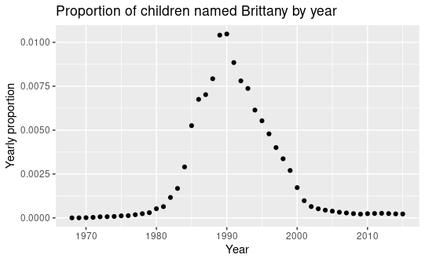

```r
brittany_data <- getNameTibble("Brittany")
brittany_data <- brittany_data %>% mutate(grandTotal = (year %>% modify(function(x) getGrandTotal(x))), propGrandTotal = Total/grandTotal)
brittany_data %>% ggplot(aes(year, propGrandTotal)) + geom_point() + labs(title="Proportion of children named Brittany by year", x="Year", y="Yearly proportion")
```

The name Brittany does not appear in the data before 1968. It looks like the popularity for the name Brittany peaked in 1990. We find this directly using R:

```r
maxBrittanyIndex <- brittany_data$propGrandTotal %>% which.max()
maxBrittanyYear <- brittany_data$year[maxBrittanyIndex]
```

This confirms that Brittany was most popular is 1990, which would make the person 31 years old. Based on the graph, I would not guess the birth year to be before 1982 nor after 2001, so I would not guess any ages below 20 and I would not guess any ages above 39.

## Challenge Question Three

Mary, Martha, Peter, and Paul are all Christian names. From 1920 - 2000, compare the name usage of each of the four names.

### Response:

We combine the data for the names Mary, Martha, Peter, and Paul in one table:

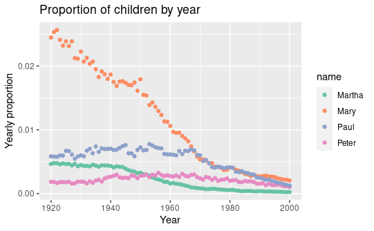

```r
mary_data <- getNameTibble("Mary") %>% filter(year >= 1920) %>%   filter(year <= 2000) %>% mutate(name = "Mary") %>% mutate(propGrandTotal = Total/(year %>% modify(function(x) getGrandTotal(x))))
martha_data <- getNameTibble("Martha") %>% filter(year >= 1920) %>% filter(year <= 2000) %>% mutate(name = "Martha") %>% mutate(propGrandTotal = Total/(year %>% modify(function(x) getGrandTotal(x))))
peter_data <- getNameTibble("Peter") %>% filter(year >= 1920) %>% filter(year <= 2000) %>% mutate(name = "Peter") %>% mutate(propGrandTotal = Total/(year %>% modify(function(x) getGrandTotal(x))))
paul_data <- getNameTibble("Paul") %>% filter(year >= 1920) %>% filter(year <= 2000) %>% mutate(name = "Paul") %>% mutate(propGrandTotal = Total/(year %>% modify(function(x) getGrandTotal(x))))
combined_data <- rbind(mary_data, martha_data, peter_data, paul_data)
combined_data %>% ggplot(aes(year, propGrandTotal, color = name)) + geom_point() + labs(title="Proportion of children by year", x="Year", y="Yearly proportion") + scale_color_brewer(palette = "Set2") # ok for color blind people
```

We can see that Mary was much more popular in 1920 than Martha, Paul and Peter. The popularity of Peter has remained fairly constant, and that the proportions for Paul and Martha decreased slowly over time. Mary experienced a large drop on popularity from 1920 to 2000.

## Challenge Question Four

Think of a unique name from a famous movie. Plot that name and see how increases line up with the movie release.

### Response:

I picked the name Harry since that was my grandfather’s name and I loved the Harry Potter books. The first Harry Potter movie was released in 2001, and later Harry Potter films were released in 2002, 2004, 2005, 2007, 2009, and 2011.

Here is a plot of the proportion of children named Harry over time:

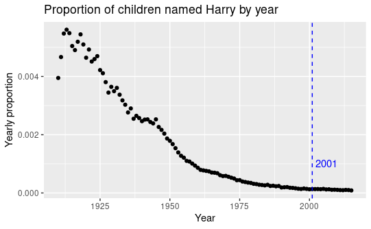

```r
harry_data <- getNameTibble("Harry")
harry_data <- harry_data %>% mutate(propGrandTotal = Total/(year %>% modify(function(x) getGrandTotal(x))))
harry_data %>% ggplot(aes(year, propGrandTotal)) + geom_point() + labs(title="Proportion of children named Harry by year", x="Year", y="Yearly proportion") + geom_vline(xintercept=2001, linetype='dashed', color='blue') + annotate("text", x = 2006, y = 0.001, label = "2001", color = "blue")
```

There does not seem to be an increase in the name Harry due to the release of the Harry Potter movies. Zooming in to the years immediately surrounding the releases of the Harry Potter movies gives the following graph:

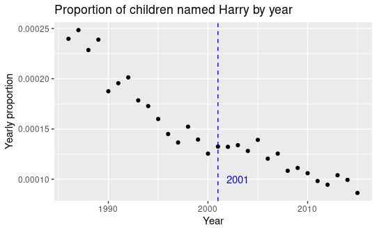

```r
harry_data %>% filter(year > 1985) %>% ggplot(aes(year, propGrandTotal)) + geom_point() + labs(title="Proportion of children named Harry by year", x="Year", y="Yearly proportion") + geom_vline(xintercept=2001, linetype='dashed', color='blue')  + annotate("text", x = 2003, y = 0.0001, label = "2001", color = "blue")
```

From this view, it seems that the decline in Harry was paused from 2001 to 2007, but that the decline then continued. It is not clear if this pause in the decline is due to the release of the Harry Potter movies.